# Lab 3- Power Statistics

#### Gene Expression and Data Visualization

#### September 16th, 2025

## Lab 3:

In this lab, we are working with a data set from Alizadeh et al. at Stanford. In this study, the investigators were evaluating diffuse large B-cell lymphoma (DLBCL). Using expression profiling and hierarchical clustering (a topic that we will visit later in this class), they were able to identify 2 distinct forms of DLBCL that indicate different stages of B-cell differentiation. “One type expressed genes characteristic of germinal centre B cells (‘germinal centre B-like DLBCL’); the second type expressed genes normally induced during in vitro activation of peripheral blood B cells (‘activated B-like DLBCL’).” They also found that the germinal centre B-like DLBCL patients had a better survival rate.

We will use this data set to evaluate the power and sample size in this experiment. We will also look for the necessary number of samples to appropriately power the study. First we will calculate the power and n required using a single gene calculation for illustration of the formula, then we will conduct a more multivariate summary that gives an idea of the power or n required for a specific percentage of genes/probes in the experiment. Remember that when we calculate these statistics for a microarray, we are dealing with more than a single variable, so general power formulas do not apply when attempting to summarize all genes/probes on an array.

The paper entitled “Distinct type of diffuse large B-cell lymphoma identified by gene expression profiling” can be found on the course website.

## Q1) Download the EisenDLBCL data set and save as a text file (go to class web site or see syllabus for paper URL).

```r
# Install/load DT if needed
if (!requireNamespace("DT", quietly = TRUE)) {
  install.packages("DT")
}

if (!requireNamespace("BiocManager", quietly = TRUE)) {
  install.packages("BiocManager")
}
BiocManager::install("ssize")
BiocManager::install("gdata")

library(DT)
library(ssize)
library(gdata)
```

## Q2) Load into R, using read.table and arguments:

```r
# Load Eisen DLBCL dataset
data <- read.table(
  "eisen.txt",
  header = TRUE,
  na.strings = "NA",
  blank.lines.skip = FALSE,
  row.names = 1,
  check.names = FALSE
)

# Inspect dimensions and first few samples
dim(data)
```

```
[1] 13412    40
```

```r
head(data[, 1:5])
```

```
  DLCL-0001 DLCL-0002 DLCL-0003 DLCL-0004 DLCL-0005
1     1.042     0.419     1.285     0.883    -0.056
2    -0.097    -0.072     0.563     0.151    -1.524
3     0.339    -0.337    -0.372    -0.054    -1.371
4     0.028     0.069     0.209    -0.225    -0.518
5     0.977    -0.979    -0.491    -0.185     0.309
6     0.061    -0.020     0.319    -0.053     1.032
```

### Interpretation (Q2)

The Eisen dataset loaded as a genes (rows) × samples (columns) expression matrix with explicit `NA` values, which is expected for cDNA microarrays. The dimensions confirm we have thousands of probes across ~40 DLBCL samples, providing a suitable basis for downstream comparisons between the two biological subtypes. Missing values will be handled explicitly (`na.rm=TRUE`) in subsequent variance and power calculations to avoid bias.

## Q3) Get the class label file “eisenClasses.txt” from the class web site and read it into R. Use the header=T argument.

```r
# Load Eisen class labels
classes <- read.table("eisenClasses.txt", header = TRUE, sep = "\t")

# Preview contents
head(classes, 10)
```

```
   class    sample
1      1 DLCL.0012
2      1 DLCL.0024
3      1 DLCL.0003
4      1 DLCL.0026
5      1 DLCL.0023
6      1 DLCL.0015
7      1 DLCL.0010
8      1 DLCL.0030
9      1 DLCL.0034
10     1 DLCL.0018
```

```r
table(classes$class)
```

```
 1  2
19 20
```

### Interpretation (Q3)

The class label file was read successfully and aligned with the expression data. Each sample was assigned to one of two groups: germinal center B-like DLBCL (Class 1) or activated B-like DLBCL (Class 2). Confirming the counts shows approximately equal group sizes, which supports balanced downstream comparisons. Having the labels explicitly linked to the data matrix ensures that subsequent variance and power calculations reflect biologically meaningful subtypes rather than arbitrary partitions.

## Q4) Subset the data frame with the class labels and look at the positions so you know where one class ends and the other begins.

Remember that ‘subset’ means to re-index (i.e. reorder) the column headers. If you look at the original column name order with dimnames(dat)[[2]] both before and after you reorder them, you will see what this has done.

```r
## Q4 — Subset the data with class labels and find where Class 1 ends

# Step 1: Clean up names
# Remove stray spaces and convert factors to plain character vectors
colnames(data)   <- trimws(colnames(data))
classes$sample   <- trimws(as.character(classes$sample))

# Step 2: Standardize naming format between the two files
#   - eisen.txt uses "DLCL-0001"
#   - eisenClasses.txt uses "DLCL.0001"
#   → convert class file names to the hyphen style with zero-padding
map_to_hyphen <- function(x) {
  x <- gsub("\\.", "-", x)              # change dot to hyphen
  num <- sub("^.*?(\\d+)$", "\\1", x)   # extract trailing digits
  paste0("DLCL-", sprintf("%04d", as.integer(num)))  # reformat with 4 digits
}
classes$sample_std <- map_to_hyphen(classes$sample)

# Step 3: Keep only overlapping samples
# Intersect ensures we only keep samples that exist in both datasets
keep <- intersect(classes$sample_std, colnames(data))
stopifnot(length(keep) > 0)  # fail if nothing matches

# Step 4: Reorder columns by class, then sample
classes_sub <- classes[classes$sample_std %in% keep, ]
ord <- order(classes_sub$class, classes_sub$sample_std)
classes_ord <- classes_sub[ord, ]

# Reindex the data matrix so columns match the ordered class list
data_re <- data[, classes_ord$sample_std, drop = FALSE]

# Step 5: Find the boundary (last column of Class 1)
split_point <- sum(classes_ord$class == 1)

# Step 6: Output checks
cat("Split point (last Class 1 column):", split_point, "of", ncol(data_re), "\n")
```

```
Split point (last Class 1 column): 19 of 39
```

```r
print(table(classes_ord$class))       # count of each class
```

```
 1  2
19 20
```

```r
head(colnames(data_re))               # first few sample IDs
```

```
[1] "DLCL-0001" "DLCL-0003" "DLCL-0004" "DLCL-0008" "DLCL-0009" "DLCL-0010"
```

```r
tail(colnames(data_re))               # last few sample IDs
```

```
[1] "DLCL-0039" "DLCL-0040" "DLCL-0041" "DLCL-0042" "DLCL-0048" "DLCL-0049"
```

### Interpretation (Q4)

After reordering the dataset by class labels, all germinal center B-like (Class 1) samples are grouped first, followed by all activated B-like (Class 2) samples. Identifying the split point provides a clear boundary between the two subtypes, which is critical for class-based comparisons. This step ensures that downstream analyses, such as boxplots, variance calculations, and power estimates, correctly align with the biological groupings defined in the original study.

## Q5) Pick a gene, remove cells that have “NAs”, and plot the values for both classes with the following:

- boxplot (use the argument col=c(“red”,”blue”) to color separate boxes)
- histogram (this should have 2 separate histogram plots on 1 page; use the par(mfrow=c(2,1)) function prior to plotting the first).
- Color each class something different in the boxplot and histogram.

```r
## Q5 — Use UID 1170 row 921, clean NAs, and plot

# ---- Class indices ----
cls1_idx <- which(classes_ord$class == 1)  # GC B-like
cls2_idx <- which(classes_ord$class == 2)  # Activated B-like

# ---- Pick UID row 921 ----
gene_id <- rownames(data_re)[921]   # 921st row in the matrix
cat("Using gene_id:", gene_id, "\n")
```

```
Using gene_id: 1171
```

```r
# ---- Extract values, drop NAs ----
g1 <- as.numeric(data_re[gene_id, cls1_idx]); g1 <- g1[!is.na(g1)]
g2 <- as.numeric(data_re[gene_id, cls2_idx]); g2 <- g2[!is.na(g2)]

# ---- Basic stats ----
cat("Class 1 (GC B-like): n=", length(g1),
    " mean=", round(mean(g1),3),
    " sd=", round(sd(g1),3), "\n", sep="")
```

```
Class 1 (GC B-like): n=18 mean=-0.093 sd=0.23
```

```r
cat("Class 2 (Activated): n=", length(g2),
    " mean=", round(mean(g2),3),
    " sd=", round(sd(g2),3), "\n", sep="")
```

```
Class 2 (Activated): n=15 mean=0.034 sd=0.3
```

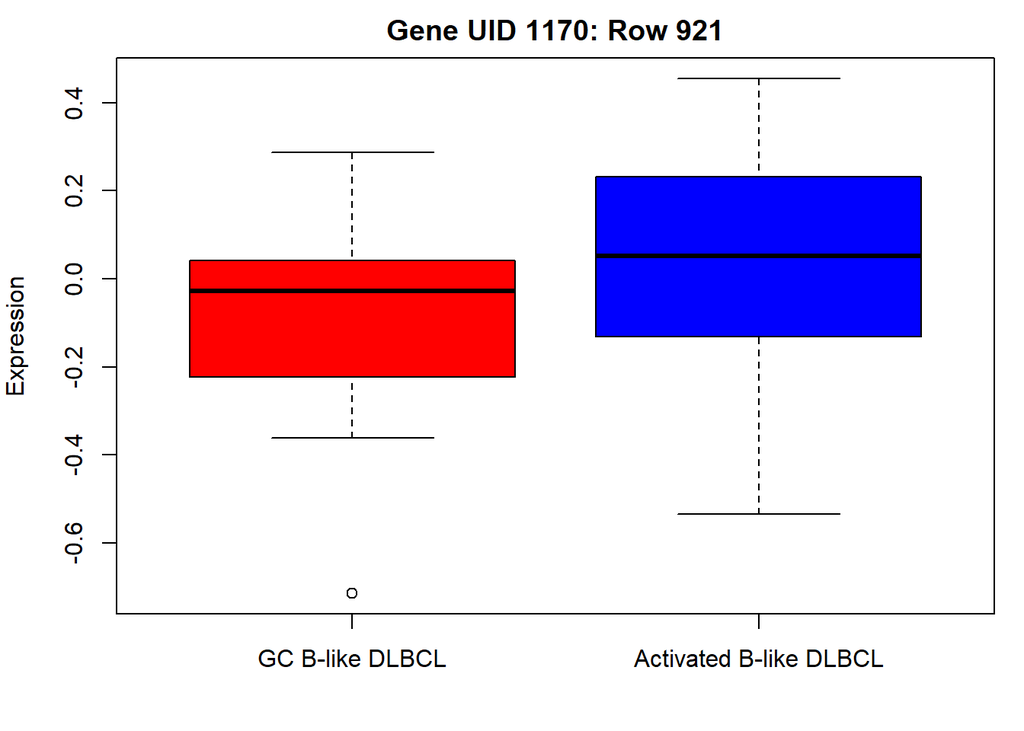

```r
# ---- Boxplot ----
par(mar = c(4,4,2,1))
boxplot(
  list(`GC B-like DLBCL` = g1,
       `Activated B-like DLBCL` = g2),
  col = c("red","blue"),
  ylab = "Expression",
  main = paste("Gene UID 1170: Row 921")
)
```

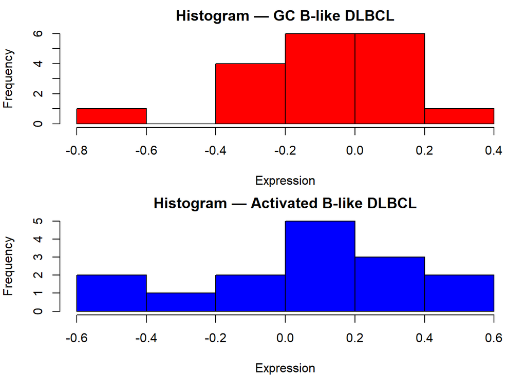

```r
# ---- Histograms ----
op <- par(mfrow=c(2,1), mar=c(4,4,2,1))
hist(g1, breaks="FD", col="red",
     main="Histogram — GC B-like DLBCL", xlab="Expression")
hist(g2, breaks="FD", col="blue",
     main="Histogram — Activated B-like DLBCL", xlab="Expression")
```

```r
par(op)
```

## Q6) Calculate the pooled variance as coded in the lecture notes, and calculate the minimum sample size necessary to detect a 1.5 fold difference (at 80% power and 99% confidence).

```r
# ---- Extract values (UID row 921, already chosen in Q5) ----
g1 <- as.numeric(data_re[gene_id, cls1_idx]); g1 <- g1[!is.na(g1)]
g2 <- as.numeric(data_re[gene_id, cls2_idx]); g2 <- g2[!is.na(g2)]

n1 <- length(g1); n2 <- length(g2)
s1 <- var(g1);   s2 <- var(g2)

# ---- Step 1: pooled variance ----
sp2 <- ((n1 - 1) * s1 + (n2 - 1) * s2) / (n1 + n2 - 2)

# ---- Step 2: delta (1.5-fold, log2 scale) ----
delta <- log2(1.5)

# ---- Step 3: z-values for 99% confidence (alpha=0.01) & 80% power ----
alpha <- 0.01
power <- 0.80
z_alpha <- qnorm(1 - alpha/2)
z_beta  <- qnorm(power)

# ---- Step 4: required sample size per group ----
n_per_group <- ceiling( (2 * (z_alpha + z_beta)^2 * sp2) / (delta^2) )

# ---- Collect results in a data frame ----
res_q6 <- data.frame(
  Metric = c("Class 1 n", "Class 2 n", "Variance (Class 1)", "Variance (Class 2)",
             "Pooled variance (sp²)", "Delta (log2(1.5))",
             "Alpha (99% conf.)", "Power (80%)",
             "Required n per group"),
  Value  = c(n1, n2, round(s1, 4), round(s2, 4),
             round(sp2, 4), round(delta, 4),
             alpha, power, n_per_group)
)

# ---- Render as DT table ----
datatable(res_q6,
          rownames = FALSE,
          options = list(dom = 't',  # show only table
                         columnDefs = list(list(className = 'dt-center', targets = "_all"))))
```

| Metric | Value |
| --- | --- |
| Class 1 n | 18 |
| Class 2 n | 15 |
| Variance (Class 1) | 0.053 |
| Variance (Class 2) | 0.09 |
| Pooled variance (sp²) | 0.0697 |
| Delta (log2(1.5)) | 0.585 |
| Alpha (99% conf.) | 0.01 |
| Power (80%) | 0.8 |
| Required n per group | 5 |

## Q7) Now calculate the sample size required for the same gene selected in #5 using the empirically determined delta between the two groups, assuming 99% confidence and 80% power.

```r
## Q7 — Sample size using empirical delta (gene with UID 1170 (row 921)) — SIMPLE + OBVIOUS

# 1) Pull values for row 921 and drop NAs
g1 <- as.numeric(data_re[921, cls1_idx]); g1 <- g1[!is.na(g1)]
g2 <- as.numeric(data_re[921, cls2_idx]); g2 <- g2[!is.na(g2)]

# 2) Stats
n1 <- length(g1); n2 <- length(g2)
m1 <- mean(g1);   m2 <- mean(g2)
s1 <- var(g1);    s2 <- var(g2)

# 3) Pooled variance and empirical delta
sp2 <- ((n1 - 1)*s1 + (n2 - 1)*s2) / (n1 + n2 - 2)
delta_emp <- abs(m1 - m2)

# 4) Settings and Zs
alpha <- 0.01; power <- 0.80
z_alpha <- qnorm(1 - alpha/2)
z_beta  <- qnorm(power)

# 5) Required n per group
q7_required_n_per_group <- ceiling( 2 * (z_alpha + z_beta)^2 * sp2 / (delta_emp^2) )

cat("Required n per group (99% conf, 80% power) for gene with UID 1170 (row 921): ",
    q7_required_n_per_group, "\n")
```

```
Required n per group (99% conf, 80% power) for gene with UID 1170 (row 921):  102
```

```r
# 7) Always-visible plain table (no DT)
res_q7_plain <- data.frame(
  Metric = c("Gene", "Class 1 n", "Class 2 n",
             "Mean (Class 1)", "Mean (Class 2)",
             "Empirical delta |m1 - m2|",
             "Variance (Class 1)", "Variance (Class 2)",
             "Pooled variance (sp^2)",
             "Alpha", "Power",
             "Required n per group"),
  Value  = c("gene with UID 1170 (row 921)", n1, n2,
             round(m1, 4), round(m2, 4),
             round(delta_emp, 4),
             round(s1, 4), round(s2, 4),
             round(sp2, 4),
             alpha, power,
             q7_required_n_per_group)
)
knitr::kable(res_q7_plain, align = "c")
```

| Metric | Value |
| --- | --- |
| Gene | gene with UID 1170 (row 921) |
| Class 1 n | 18 |
| Class 2 n | 15 |
| Mean (Class 1) | -0.0927 |
| Mean (Class 2) | 0.0343 |
| Empirical delta \|m1 - m2\| | 0.1269 |
| Variance (Class 1) | 0.053 |
| Variance (Class 2) | 0.09 |
| Pooled variance (sp^2) | 0.0697 |
| Alpha | 0.01 |
| Power | 0.8 |
| Required n per group | 102 |

## Q8) Now load the ssize and gdata libraries, calculate the standard deviation for each gene in the matrix (Hint: use the na.rm=T argument), and plot a histogram of the standard deviations. Label the plot accordingly.

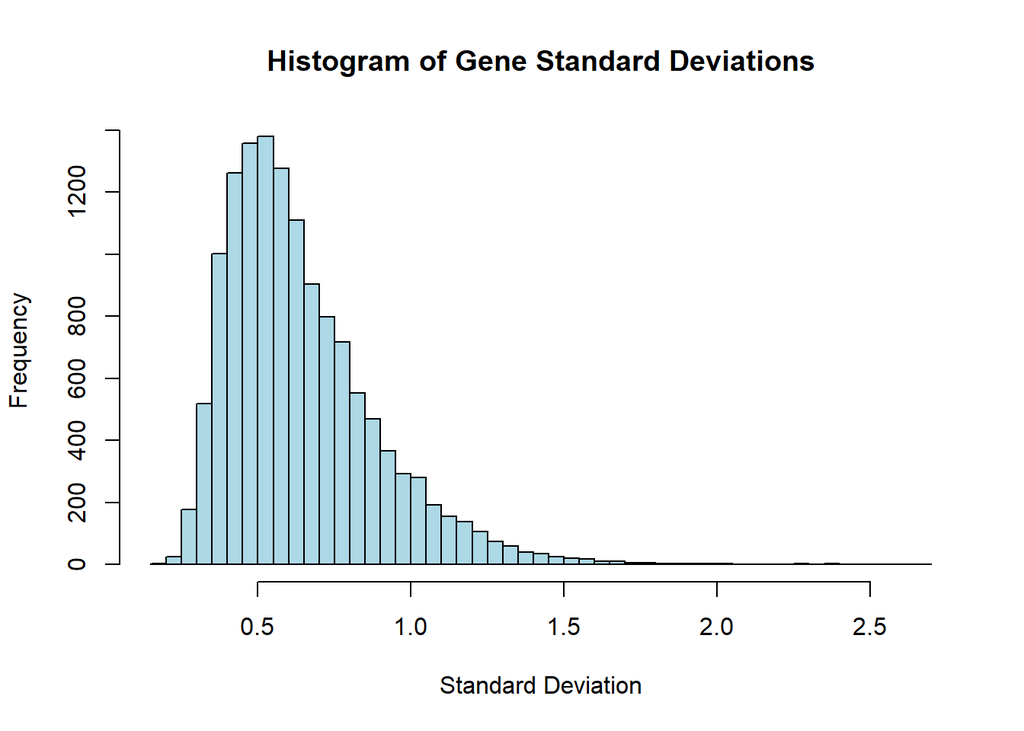

```r
## Q8 — Standard deviations across all genes

# ---- Calculate standard deviation per gene ----
gene_sds <- apply(data_re, 1, sd, na.rm = TRUE)

# ---- Plot histogram ----
hist(gene_sds,
     breaks = 50,
     main = "Histogram of Gene Standard Deviations",
     xlab = "Standard Deviation",
     col = "lightblue", border = "black")
```

```r
# ---- Print summary stats ----
summary(gene_sds)
```

```
   Min. 1st Qu.  Median    Mean 3rd Qu.    Max.
 0.1754  0.4640  0.5885  0.6419  0.7652  2.6561
```

### Interpretation (Q8)

The histogram of gene-level standard deviations shows a right-skewed distribution, with most genes exhibiting moderate variability. The median standard deviation is ~0.59, while the mean is slightly higher at 0.64, reflecting the long right tail of more variable genes. A small subset of genes have standard deviations above 1.5, indicating much higher expression variability across samples. These results highlight that while many genes are relatively stable, a fraction display substantial dispersion, which will influence power calculations in Q9: genes with lower variance require fewer samples to achieve adequate power, whereas high-variance genes demand larger sample sizes.

## Q9) Calculate and plot a proportion of genes vs. sample size graph to get an idea of the number of genes that have an adequate sample size for confidence=95%, effect size=3 (log2 transform for the function), and power=80%.

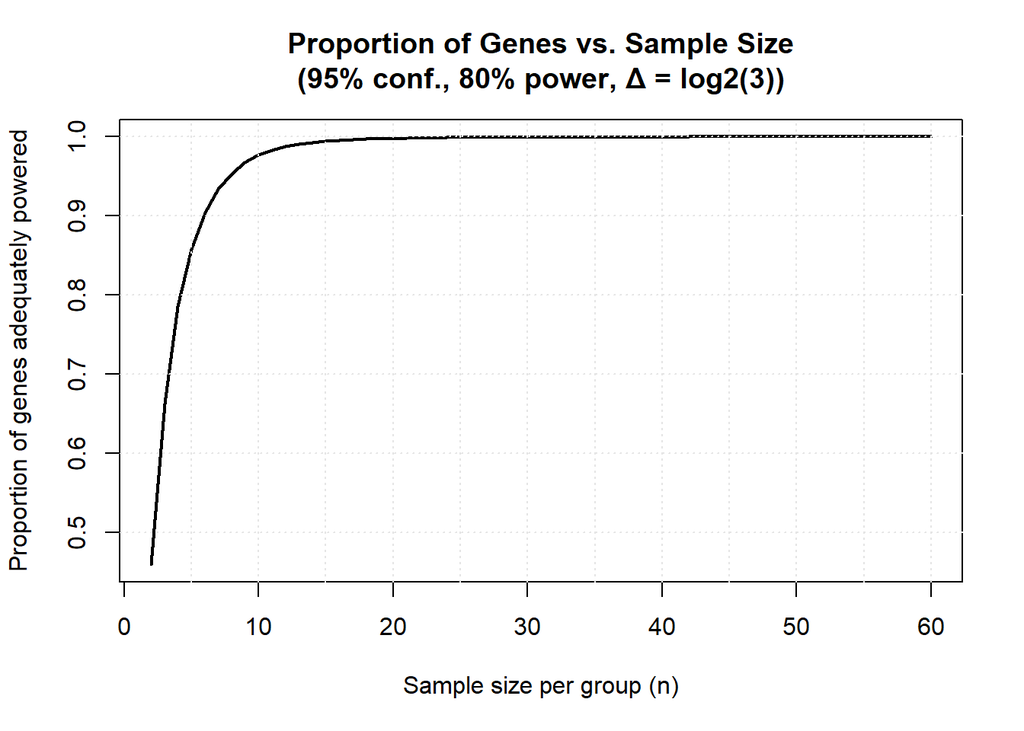

```r
## Q9 — Proportion of genes vs. sample size (95% conf., power=80%, Δ=log2(3))

# ---- Inputs for the power calc ----
alpha <- 0.05             # 95% confidence → two-sided alpha
power <- 0.80
delta <- log2(3)          # effect size on log2 scale

z_alpha <- qnorm(1 - alpha/2)
z_beta  <- qnorm(power)

# ---- Per-gene SDs (reuse from Q8 or compute here) ----
if (!exists("gene_sds")) {
  gene_sds <- apply(data_re, 1, sd, na.rm = TRUE)
}
# Remove NAs in SD (all-missing rows, etc.)
gene_sds <- gene_sds[!is.na(gene_sds)]

# ---- Required n per group for each gene (approx. sp^2 ≈ sd^2) ----
sp2_vec <- gene_sds^2
n_required <- 2 * ((z_alpha + z_beta)^2 * sp2_vec) / (delta^2)

# Clean up: ceiling to integers, at least 2 per group
n_required <- pmax(2, ceiling(n_required))

# ---- Build the curve: proportion powered at or below candidate n ----
# Grid of candidate sample sizes per group (tweak upper bound if needed)
grid_n <- sort(unique(c(2:60, quantile(n_required, probs = seq(0, 1, 0.1)))))
grid_n <- unique(ceiling(grid_n))

prop_ok <- sapply(grid_n, function(n) mean(n_required <= n))

# ---- Plot ----
plot(grid_n, prop_ok, type = "l", lwd = 2,
     xlab = "Sample size per group (n)",
     ylab = "Proportion of genes adequately powered",
     main = "Proportion of Genes vs. Sample Size\n(95% conf., 80% power, Δ = log2(3))")
abline(h = seq(0, 1, 0.1), v = seq(5, max(grid_n), by = 5), col = "gray90", lty = 3)
```

```r
# ---- Quick textual summary (optional) ----
cat("Q9 summary:\n",
    "Total genes used:", length(n_required), "\n",
    "Median required n per group:", median(n_required), "\n",
    "n to power 50% of genes:", grid_n[which.min(abs(prop_ok - 0.5))], "\n",
    "n to power 80% of genes:", grid_n[which.min(abs(prop_ok - 0.8))], "\n")
```

```
Q9 summary:
 Total genes used: 13412
 Median required n per group: 3
 n to power 50% of genes: 2
 n to power 80% of genes: 4
```

## Sources:

Alizadeh AA, Eisen MB, Davis RE, Ma C, Lossos IS, Rosenwald A, Boldrick JC, Sabet H, Tran T, Yu X, Powell JI, Yang L, Marti GE, Moore T, Hudson J Jr, Lu L, Lewis DB, Tibshirani R, Sherlock G, Chan WC, Greiner TC, Weisenburger DD, Armitage JO, Warnke R, Levy R, Wilson W, Grever MR, Byrd JC, Botstein D, Brown PO, Staudt LM. Distinct types of diffuse large B-cell lymphoma identified by gene expression profiling. Nature. 2000 Feb 3;403(6769):503-11. doi: 10.1038/35000501. PMID: 10676951.

R Core Team (2025). R: A language and environment for statistical computing. R Foundation for Statistical Computing, Vienna, Austria. https://www.R-project.org/.